# 02: Practical: R / Bioconductor and Reproducible Research

Martin Morgan

Roswell Park Comprehensive Cancer Center

juillet 01, 2019

# 1 Start your markdown document

Create a new `.Rmd` file

- Select the RStudio menu item “File” -> “New File” -> “R Markdown…”
- Fill in the Title and Author fields, and select an “HTML” document

Process the `.Rmd` file

- Click on the “Knit” icon
- At prompt, save file with name “Notes.Rmd” somewhere on your computer.

Anatomy

- ‘YAML’ header with information about the document

  ```
  ---
  title: "Notes"
  author: "Martin Morgan"
  date: "6/30/2019"
  output: html_document
  ---
  ```

- Plain text ‘markdown’
  - `#`: top level heading; `##` second level heading, …
  - Plain text paragraphs, separated by empty lines
  - *R* code chunks

More help on markdown under “Help” -> "Markdown Quick Reference

**Exercise** To get going, leave the YAML header, but remove everything else.

# 2 Working with data

## 2.1 `library()`, `install.packages()`, and `BiocManager::install()`

We’ll use the following libraries; attach them to your current *R* session.

```r
library(readr)
library(dplyr)
library(BiocStyle)
```

If *R* responds

```
Error in library(readr) : there is no package called 'readr'
```

or similar, it means that the library needs to be installed. The ‘*Bioconductor*’ way of library installation (able to install *CRAN* and *Bioconductor* packages) is to use the BiocManager package. Make sure you have the `BiocManager` package installed

```r
if (!requireNamespace("BiocManager", quietly = TRUE))
    install.packages("BiocManager")
```

then install the packages you need

```r
BiocManager::install(c("readr", "dplyr"))
```

## 2.2 `read_csv()`

Find the data file “ALL-sample-sheet.csv”

```r
pdata_file <- file.choose()
```

then input the data using `read_csv()`

```r
pdata <- read_csv(pdata_file)
```

If *R* responds

```
Error in read_csv() : could not find function "read_csv"
```

this means that the `readr` package has not been attached to the *R* session; remedy with `library(readr)`.

Take a peak at the data to see what we have

```r
pdata
```

```
## # A tibble: 128 x 22
##    sample cod   diagnosis sex     age BT    remission CR    date.cr
##    <chr>  <chr> <chr>     <chr> <dbl> <chr> <chr>     <chr> <chr>
##  1 01005  1005  5/21/1997 M        53 B2    CR        CR    8/6/19~
##  2 01010  1010  3/29/2000 M        19 B2    CR        CR    6/27/2~
##  3 03002  3002  6/24/1998 F        52 B4    CR        CR    8/17/1~
##  4 04006  4006  7/17/1997 M        38 B1    CR        CR    9/8/19~
##  5 04007  4007  7/22/1997 M        57 B2    CR        CR    9/17/1~
##  6 04008  4008  7/30/1997 M        17 B1    CR        CR    9/27/1~
##  7 04010  4010  10/30/19~ F        18 B1    CR        CR    1/7/19~
##  8 04016  4016  2/10/2000 M        16 B1    CR        CR    4/17/2~
##  9 06002  6002  3/19/1997 M        15 B2    CR        CR    6/9/19~
## 10 08001  8001  1/15/1997 M        40 B2    CR        CR    3/26/1~
## # ... with 118 more rows, and 13 more variables: `t(4;11)` <lgl>,
## #   `t(9;22)` <lgl>, cyto.normal <lgl>, citog <chr>, mol.biol <chr>,
## #   `fusion protein` <chr>, mdr <chr>, kinet <chr>, ccr <lgl>,
## #   relapse <lgl>, transplant <lgl>, f.u <chr>, `date last seen` <chr>
```

This represents 22 variables collected on 128 samples from a classic microarray experiment. Some of the column names are cryptic; we’ll only focus on a few.

# 3 Update your markdown document

Add a top-level section title (start a line with `#`) like

```
# Day 1: R / Bioconductor practical
```

Add notes about the key functions you’ve learned about so far, using a bulleted list like

```
Key functions:

- `file.choose()`: interactively choose a file location.
- `library(readr)`: attach the readr package to the current _R_ session
- `read_csv()`
```

Press the ‘Knit’ button, debugging any errors that occur.

Create a code chunk containing instructions for data input, using a ‘fence’ followed by `{r}`

````
```{r}
library(readr)
pdata_file = "path/to/file"
pdata <- readr(pdata_file)
pdata
```
````

Press the ‘Knit’ button. Note that the code is actually evaluated, and when correct will import the data from the `pdata_file`.

# 4 Working with data (continued): exploration

## 4.1 `arrange()`

Use `arrange()` to order the rows from youngest to oldest individual

```r
pdata %>% arrange(age)
```

```
## # A tibble: 128 x 22
##    sample cod   diagnosis sex     age BT    remission CR    date.cr
##    <chr>  <chr> <chr>     <chr> <dbl> <chr> <chr>     <chr> <chr>
##  1 08018  8018  8/27/1999 M         5 B3    CR        CR    10/18/~
##  2 19017  19017 3/17/2000 M        14 T2    CR        CR    6/15/2~
##  3 06002  6002  3/19/1997 M        15 B2    CR        CR    6/9/19~
##  4 25003  25003 5/22/1998 M        15 B2    CR        CR    8/4/19~
##  5 04016  4016  2/10/2000 M        16 B1    CR        CR    4/17/2~
##  6 24010  24010 6/3/1997  F        16 B2    CR        CR    8/11/1~
##  7 24019  24019 5/4/1999  M        16 B4    CR        CR    7/28/1~
##  8 28001  28001 10/19/19~ M        16 B3    REF       REF   <NA>
##  9 28044  28044 7/20/1999 M        16 B3    CR        CR    9/20/1~
## 10 01007  1007  9/30/1998 F        16 T3    CR        CR    11/30/~
## # ... with 118 more rows, and 13 more variables: `t(4;11)` <lgl>,
## #   `t(9;22)` <lgl>, cyto.normal <lgl>, citog <chr>, mol.biol <chr>,
## #   `fusion protein` <chr>, mdr <chr>, kinet <chr>, ccr <lgl>,
## #   relapse <lgl>, transplant <lgl>, f.u <chr>, `date last seen` <chr>
```

If *R* responds with

```
> pdata %>% arrange(age)
Error in pdata %>% summarize(n = n()) : could not find function "%>%"
```

then we need to attach the `dplyr` package, `library(dplyr)`.

Arrange from oldest to youngest with

```r
pdata %>% arrange(desc(age))
```

```
## # A tibble: 128 x 22
##    sample cod   diagnosis sex     age BT    remission CR    date.cr
##    <chr>  <chr> <chr>     <chr> <dbl> <chr> <chr>     <chr> <chr>
##  1 16004  16004 4/19/1997 F        58 B1    CR        CR    7/15/1~
##  2 20002  20002 5/9/1997  F        58 B2    CR        CR    8/19/1~
##  3 04007  4007  7/22/1997 M        57 B2    CR        CR    9/17/1~
##  4 24017  24017 9/15/1998 M        57 B2    CR        CR    12/7/1~
##  5 08012  8012  10/22/19~ M        55 B3    CR        CR    1/9/19~
##  6 28021  28021 3/18/1998 F        54 B3    CR        DEAT~ 5/22/1~
##  7 30001  30001 1/16/1997 F        54 B3    <NA>      DEAT~ <NA>
##  8 43007  43007 10/14/19~ M        54 B4    CR        CR    12/30/~
##  9 62002  62002 1/15/1998 M        54 B4    <NA>      DEAT~ <NA>
## 10 01005  1005  5/21/1997 M        53 B2    CR        CR    8/6/19~
## # ... with 118 more rows, and 13 more variables: `t(4;11)` <lgl>,
## #   `t(9;22)` <lgl>, cyto.normal <lgl>, citog <chr>, mol.biol <chr>,
## #   `fusion protein` <chr>, mdr <chr>, kinet <chr>, ccr <lgl>,
## #   relapse <lgl>, transplant <lgl>, f.u <chr>, `date last seen` <chr>
```

**Exercise** How would you use `arrange()` to order the samples from youngest to oldest, with individuals of equal `age` ordered by `sex`?

## 4.2 `summarize()` and `group_by()`

```r
pdata %>% summarize(n = n())
```

```
## # A tibble: 1 x 1
##       n
##   <int>
## 1   128
```

We now know how many samples there are. Use `group_by()` to tell `dplyr` to separately consider each sex

```r
pdata %>% group_by(sex)
```

and then perform the summary operation…

```r
pdata %>% group_by(sex) %>% summarize(n = n())
```

```
## # A tibble: 3 x 2
##   sex       n
##   <chr> <int>
## 1 F        42
## 2 M        83
## 3 <NA>      3
```

**Exercise** What is the `NA` sex? Use `filter()` to identify the 3 records with `is.na(sex)`.

**Exercise** Use `arrange()` and `desc()` to arrange the summary table from most to least frequent.

**Exercise** Add another column `ave_age` to `summarize()`, using `mean()` to calculate the average age by sex. You’ll need to use the `na.rm = TRUE` argument to calculate an average age in the face of missing values.

## 4.3 `t.test()`, an untidy function

We’d like to compare the average age of males and females in the study using `t.test()`. `t.test()` takes a formula `age ~ sex` (`age` as a function of `sex`) describing the comparison that we’d like to make. It also takes an argument `data=` that contains the data we’d like to perform the t-test on. Unlike functions we’ve encountered so far where the data to be processed is the first argument, `t.test()` expects the data as the second argument. To adapt `t.test()` for use, we need to explicitly indicate that the data should be the second argument. One way of doing this is to use the special symbol `.` to represent the location of the incoming data, invoking `t.test(age ~ sex, data = .)`:

```r
pdata %>% t.test(age ~ sex, data = .)
```

**Exercise** Perform a t-test to ask whether there is evidence of differences in ages between the sexes. How can we change the default value of `var.equal` to `TRUE`? Is this appropriate?

**Exercise (advanced)** The return value of `t.test()` doesn’t fit well with `tidy` data analysis, because it is a complicated object that is not represented as a `tibble` and hence cannot be computed upon using the common tidy verbs. Write a simple function `t_test()` that is more tidy-friendly, accepting `data =` as it’s first argument, using `t.test()` internally to compute results, and returning a `tibble` containing results formatted for subsequent computation. Explore the broom`::tidy()` function as a way to transform many base *R* objects into tidy-friendly data structures.

## 4.4 `filter()` and `%in%`

Take a look at the `mol.biol` column, using `group_by()` and the convenience function `count()`

```r
pdata %>%
    group_by(mol.biol) %>%
    count()
```

```
## # A tibble: 6 x 2
## # Groups:   mol.biol [6]
##   mol.biol     n
##   <chr>    <int>
## 1 ALL1/AF4    10
## 2 BCR/ABL     37
## 3 E2A/PBX1     5
## 4 NEG         74
## 5 NUP-98       1
## 6 p15/p16      1
```

These represent chromosomal events such as the presence of the BCR/ABL fusion gene, or NEG (standard) chromosomes.

**Exercise** Use `filter()` to create a new data set `bcrabl` that contains all 22 columns but only the BCR/ABL and NEG rows. It will be helpful to use the `%in%` operator, which returns TRUE when an object in the set on the left-hand side is present in the object on the right-hand side.

```r
c("a", "b", "c", "b", "a") %in% c("a", "c")
```

```
## [1]  TRUE FALSE  TRUE FALSE  TRUE
```

**Exercise** Use `t.test()` to ask whether there are age differences between these molecular biologies.

# 5 Update your markdown document

Continue your markdown document by summarizing in a bulleted list the key functions covered in this section. Include examples of code inside fences, and make sure the code is evaluated when the “Knit” button is pressed.

# 6 Working with data (continued): visualization

## 6.1 `ggplot()`

Load the `ggplot2` library.

```r
library(ggplot2)
```

Plots are created by providing a source for the data to be displayed, as well as ‘aesthetics’ `aes()` describing the data to be used.

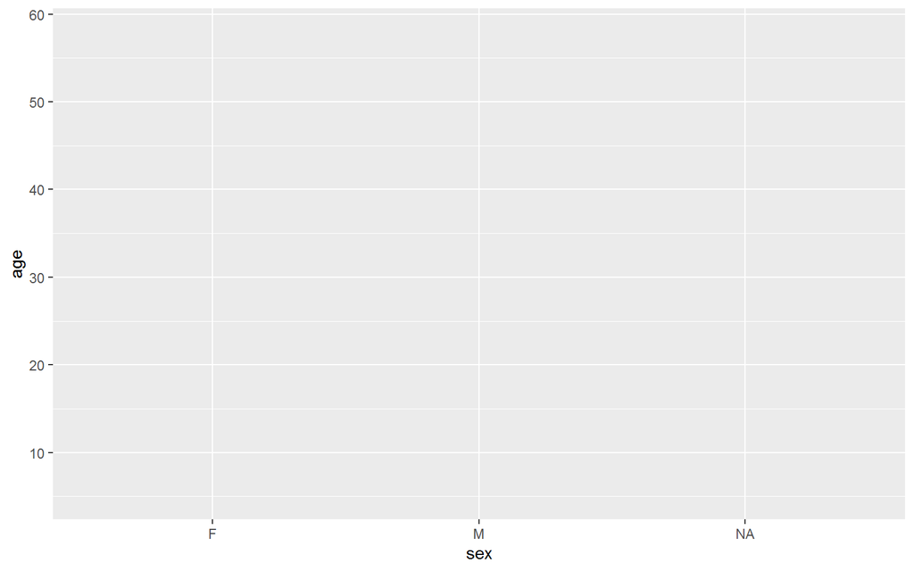

```r
ggplot(pdata, aes(x = sex, y = age))
```

## 6.2 `geom_boxplot()`

This is enough to determine the overall dimensions of the display, but we still need to add ‘geometric’ `geom_*()` objects that display the relationships of interest. Add a boxplot geom for an initial visualization.

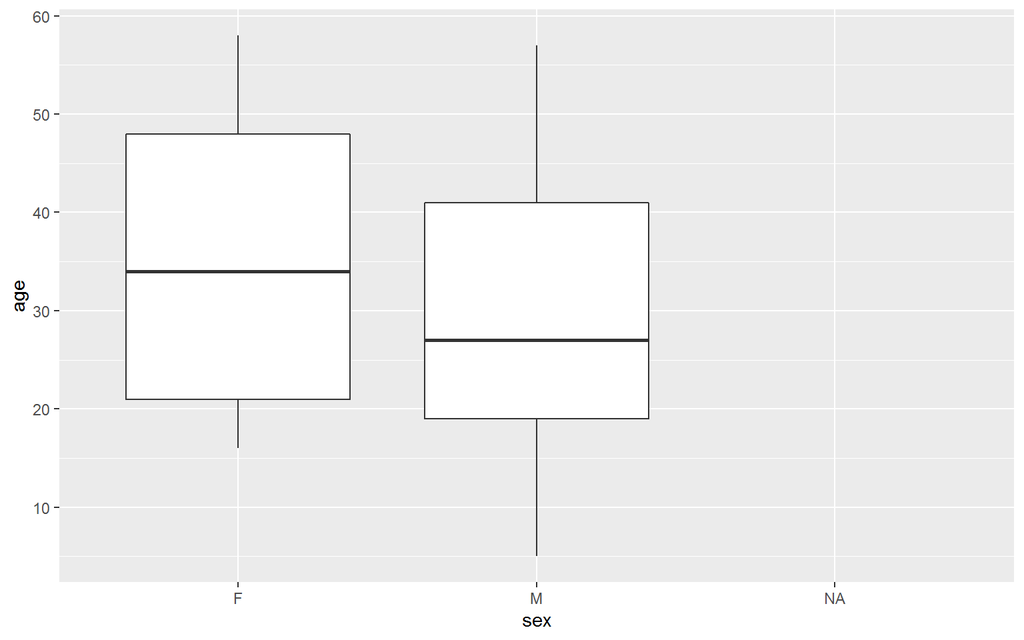

```r
ggplot(pdata, aes(x = sex, y = age)) +
    geom_boxplot()
```

## 6.3 `geom_jitter()`

Add a second layer that superimposes the actual data using `geom_jitter()` invoked so that the `sex` value is displaced a random amount about its horizontal location (`width = .1`) while the age is plotted at its actual vertical location (`height = 0`).

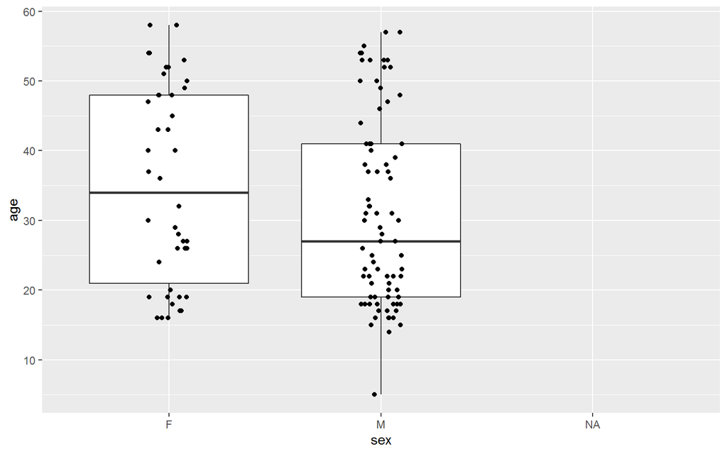

```r
ggplot(pdata, aes(x = sex, y = age)) +
    geom_boxplot() +
    geom_jitter(width = .1, height = 0)
```

**Exercise** Are there other displays that convey both the summary of results and the actual data?

# 7 Update your markdown document

# 8 Working with data (continued): *Bioconductor* objects

Create a short character vector of DNA sequences.

```r
sequences <- c("AAATCGA", "ATACAACAT", "TTGCCA")
```

In base *R* we can ask about properties of these sequences and perform some operations

```r
sequences
```

```
## [1] "AAATCGA"   "ATACAACAT" "TTGCCA"
```

```r
length(sequences)
```

```
## [1] 3
```

```r
nchar(sequences)
```

```
## [1] 7 9 6
```

```r
sequences[c(1, 3)]
```

```
## [1] "AAATCGA" "TTGCCA"
```

```r
sample(sequences)
```

```
## [1] "TTGCCA"    "AAATCGA"   "ATACAACAT"
```

Base *R* has no notion of operations relevant to DNA sequences, e.g.,

```r
reverseComplement(sequences)
```

fails. Likewise, we can name a variable anything, the semantic meaning of the variable name is not enforced by *R*

```r
my_sequence <-
    "All the world's a stage, And all the men and women merely players"
```

## 8.1 `library(Biostrings)`

Load the Biostrings library

```r
library(Biostrings)
```

If *R* responds with

```
> library(Biostrings)
Error in library(Biostrings) : there is no package called 'Biostrings'
```

then it is necessary to install the package first (make sure you’ve spelt the package name correctly, including capitalization!)

```r
if (!requireNamespace("BiocManager", quietly = TRUE))
    install.packages("BiocManager")
BiocManager::install("Biostrings")
library(Biostrings)
```

## 8.2 `DNAStringSet()`

Create a `DNAStringSet` from our character vector

```r
dna <- DNAStringSet(sequences)
dna
```

```
##   A DNAStringSet instance of length 3
##     width seq
## [1]     7 AAATCGA
## [2]     9 ATACAACAT
## [3]     6 TTGCCA
```

**Exercise** Does the object `dna` support the operations illustrated above for a character vector, especially `length()`, `nchar()`, `[`, and `sample()`?

**Exercise** Prove to yourself that at least some other useful, DNA-specific, functions exist, e.g., `reverse()` and `reverseComplement()`.

**Exercise** What happens when you try to create a `DNAStringSet()` from an object such as `my_sequence`, defined above, that does not contain a DNA sequence? Warning: the message is quite cryptic, can you provide a ‘human’ translation?

**Exercise** Why does `DNAStringSet("ACGTMRW")` not create an error, since `MRW` are not standard nucleotides? For hints, see the section ’The DNA alphabet:" on the help page `?DNAString`.

## 8.3 `methods()`, help, and `browseVignettes()`

The function `DNAStringSet()` returns an *object* that has a particular class

```r
class(dna)
```

```
## [1] "DNAStringSet"
## attr(,"package")
## [1] "Biostrings"
```

Associated with the class are a series of *methods* that operate on the class.

**Exercise** Discover many (unfortunately, not all) methods acting on an object of class `DNAStringSet` using `methods(class = "DNAStringSet")`. Verify that `reverseComplement` is among those methods.

Help pages describing a particular method can be found using `?`, with the search query quoted and with tab-completion providing hints on what the appropriate help topic is.

**Exercise** Find the help page for the `reverseComplement` method operating on a `DNAStringSet` object, using `?"reverseComplement,DNAStringSet-method"`.

Help pages provide a description of the technical details required for creating classes and using methods. Vignettes provide a more narrative description of overall package use.

**Exercise** Use `browseVignettes(package = "Biostrings")` to see vignettes available for this package; explore a few vignettes to get a sense of possible content.

## 8.4 `readDNAStringSet()`

It is unlikely that we would enter 1000’s of DNA sequences ‘by hand’. Instead, we might read the data from a standard file format. For DNA sequences the standard file format is often a ‘FASTA’ file, sometimes abbreviated with an extension `.fa` and often compressed with an additional extension `.fa.gz`. An example of a FASTA file containing DNA sequences of the 2000bp upstream nucleotides of all genes annotated in the *Drosophila melanogaster* `dm3` genome build, is distributed with the Biostrings package. Here’s the path to the FASTA file.

```r
fa_file <-
    system.file(package="Biostrings", "extdata", "dm3_upstream2000.fa.gz")
```

**Exercise** Take a peak at the structure of a FASTA file by looking at the first five lines.

```r
readLines(fa_file, 5)
```

```
## [1] ">NM_078863_up_2000_chr2L_16764737_f chr2L:16764737-16766736"
## [2] "gttggtggcccaccagtgccaaaatacacaagaagaagaaacagcatctt"
## [3] "gacactaaaatgcaaaaattgctttgcgtcaatgactcaaaacgaaaatg"
## [4] "tttttgtgcttttcgaacaaaaaattgggagcagaatattggattcgctt"
## [5] "ttttcgcatcgaatatcttaagggagcaagggaagaaccatctagaataa"
```

The first line is an identifier, containing information about the gene `NM_078863` as well as the genomic coordinates of the sequence `chr2L:16764737-16766736`. The next lines are the DNA sequence. After a certain number of lines, a new record starts.

```r
tail(readLines(fa_file, 44), 5)
```

```
## [1] "cacgcacaccgatcgtcgaatcgaaaagctttcggggtcttacgggatcc"
## [2] "atgggtatcaagttgccccgtataaaaggcaagtttaccggttgcacggt"
## [3] ">NM_001201794_up_2000_chr2L_8382455_f chr2L:8382455-8384454"
## [4] "ttatttatgtaggcgcccgttcccgcagccaaagcactcagaattccggg"
## [5] "cgtgtagcgcaacgaccatctacaaggcaatattttgatcgcttgttagg"
```

We could fairly ‘easily’ write our own parser for this format, but this would be error-prone and unnecessary.

**Exercise** Input the file

```r
dna <- readDNAStringSet(fa_file)
dna
```

```
##   A DNAStringSet instance of length 26454
##         width seq                                      names
##     [1]  2000 GTTGGTGGCCCACCAGTGC...GTTTACCGGTTGCACGGT NM_078863_up_2000...
##     [2]  2000 TTATTTATGTAGGCGCCCG...CGGAAAGTCATCCTCGAT NM_001201794_up_2...
##     [3]  2000 TTATTTATGTAGGCGCCCG...CGGAAAGTCATCCTCGAT NM_001201795_up_2...
##     [4]  2000 TTATTTATGTAGGCGCCCG...CGGAAAGTCATCCTCGAT NM_001201796_up_2...
##     [5]  2000 TTATTTATGTAGGCGCCCG...CGGAAAGTCATCCTCGAT NM_001201797_up_2...
##     ...   ... ...
## [26450]  2000 ATTTACAAGACTAATAAAG...ATTAAATTTCAATAAAAC NM_001111010_up_2...
## [26451]  2000 GATATACGAAGGACGACCT...TTTGAGTTGTTATATATT NM_001015258_up_2...
## [26452]  2000 GATATACGAAGGACGACCT...TTTGAGTTGTTATATATT NM_001110997_up_2...
## [26453]  2000 GATATACGAAGGACGACCT...TTTGAGTTGTTATATATT NM_001276245_up_2...
## [26454]  2000 CGTATGTATTAGTTAACTC...AAGTGTAAGAACAAATTG NM_001015497_up_2...
```

**Exercise** Query the object for basic properties, e.g., it’s `length()` and that the number of characters in each sequence is 2000 `unique(nchar(dna))`.

## 8.5 `letterFrequency()`: calculate GC content

**Exercise** Use `letterFrequency()` to determine GC content of each of the DNA sequences in `dna`. The `letters` argument should be `"GC"`; `as.prob = TRUE` returns values between 0 and 1. The data is returned as a matrix with 1 column.

**Exercise** Plot the distribution of GC frequencies in the `dna` object using base graphics `hist()` and `plot(density())`, and using `ggplot()`.

## 8.6 Tidy *Bioconductor*?

Although *Bioconductor* emphasizes formal objects like `DNAStringSet` rather than `tibble`-like data frames, some of the ways one interacts with tidy data can be applied to *Bioconductor* objects. For instance, the GC content example might be written in ‘traditional’ form as

```r
gc <- letterFrequency(dna, "GC", as.prob = TRUE)
```

but could be written using pipes and to reesult in a tibble for easier down-stream manipulation

```r
gc <-
    dna %>%
    letterFrequency("GC", as.prob = TRUE) %>%
    tibble::as_tibble()
gc
```

```
## # A tibble: 26,454 x 1
##    `G|C`
##    <dbl>
##  1 0.378
##  2 0.43
##  3 0.43
##  4 0.43
##  5 0.43
##  6 0.43
##  7 0.43
##  8 0.43
##  9 0.43
## 10 0.43
## # ... with 26,444 more rows
```

**Exercise** Revise other code, above, to follow this style of analysis. Are there merits / limitations of base verses ‘tidy’ approaches?

**Exercise** Are there reasons why we did not just put our `sequences` vector of DNA sequences into a `tibble`, and go from there?

# 9 Update your markdown document

Add further notes to the markdown document summarizing the functions and objects you’ve learned in this practical.

# 10 Provenance: finish your markdown document

Finish your markdown document with a fenced section that evaluates the `sessionInfo()` command.

````
```{r}
sessionInfo()
```
````